# Aside

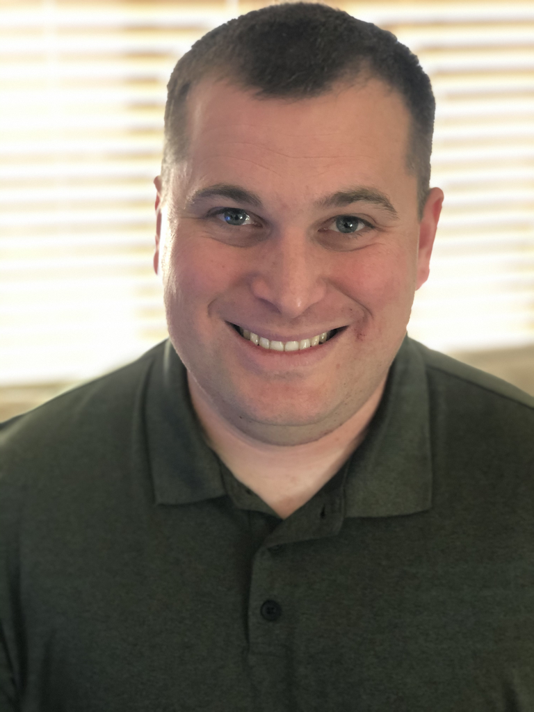

Operations Research System Analyst, Data Scientist

## Contact Info

- Email
- [GitHub](https://github.com/evan-l-munson)
- LinkedIn
- [X](https://x.com/spot2ring)
- 1 (602) 510-3047

## Skills

- -Palantir Foundry; Maven Smart System (MSS)
- -R and RStudio; R Shiny application development; R package development
- -Power BI; Microsoft 365
- -Operations research, data visualization, and decision support
- -Knowledge management; process design;

## Disclaimer

Made with the R package [**pagedown**](https://github.com/rstudio/pagedown).

Last updated on: 06 September 2026.

# Main

## Evan L. Munson

Operations research and data/decision analytics leader serving as an active-duty U.S. Army Lieutenant Colonel at Army Sustainment Command. Brings 20+ years of leadership and technical experience applying operations research, data engineering, analytics, and decision-support methods to complex operational problems. Builds data products, analytical workflows, and stakeholder partnerships that turn complex information into usable decisions; planning retirement and transition to a mission-focused technology, defense, or data-product leadership role in 2029.

## Education

### Air Force Institute of Technology

M.S in Operations Research, Certificate in Data Science

Dayton, OH

2016–2018

### Missouri University of Science and Technology

M.S. in Engineering Management.

Rolla, MO

2011–2012

### The University of Arizona

B.S. in Civil Engineering

Tucson, AZ

2001–2006

## Work Experience

### ORSA, Special Activities Group

Army Sustainment Command

Rock Island Arsenal, IL

2026–Present

- Serves as an Operations Research Systems Analyst (ORSA) for U.S. Army Sustainment Command, supporting data and decision-analytics initiatives across the Army sustainment enterprise. Scopes, develops, and deploys data products and analytical solutions using Army Vantage (Palantir Foundry) and Maven Smart Systems, integrating data engineering, data analysis, and data-science methods. Partners with stakeholders to translate operational requirements into usable, decision-ready information and repeatable analytical workflows.

### Deputy, Operational Data Team and Division ORSA

11th Airborne Division

JBER, AK

2025-2026

- Helped establish and operationalize the Division’s operational data capability, integrating data engineering, analytics, governance, and data-literacy practices into planning and decision-support processes.
- Led development and operationalization of Army Vantage and Maven Smart System capabilities and supporting workflows for the Division. Digitized and improved recurring decision-support products, including leadership update briefs, incident analysis, assessment working groups, and exercise-planning frameworks, improving the availability and usability of decision-ready information.

### Deputy, Command Data Office and Division ORSA

11th Airborne Division

JBER, AK

2024–2025

- Serves as the Command Data Office Deputy for the 11th Airborne Division. Responsibilities include establishing, developing and operationalizing data operations, data engineering, data analysis and data literacy across the DIV.
- Support the Division applying qualitative and quantitative analysis to support planning activities; assisting the Division staff with developing models, methods, and tools to fulfill mission requirements; conducting assessments that measure the Division’s readiness and its ability to conduct its mission; and concisely communicating results to decision makers.

### Deputy, Knowledge Management and Division ORSA

11th Airborne Division

JBER, AK

2023–2024

- Serves as the Knowledge Management Deputy for the 11th Airborne Division. Responsibilities include developing and implementing strategies and initiatives to enhance the Division’s overall effectiveness and efficiency.
- Support the Division applying qualitative and quantitative analysis to support planning activities; assisting the Division staff with developing models, methods, and tools to fulfill mission requirements; conducting assessments that measure the Division’s readiness and its ability to conduct its mission; and concisely communicating results to decision makers.

### Division ORSA

11th Airborne Division

JBER, AK

2022–2023

- Serves as the 11th Airborne Division’s Operations Research Systems Analyst (ORSA); provides analytic expertise toward enhancing the Commander’s understanding of the operating environment in both tactical and garrison settings.
- Responsibilities include applying qualitative and quantitative analysis to support planning activities; assisting the Division staff with developing models, methods, and tools to fulfill mission requirements; conducting assessments that measure the Division’s readiness and its ability to conduct its mission; and concisely communicating results to decision makers.

### Chief, Data Science Operations

Network Enterprise Technology Command

Fort Huachuca, AZ

2021–2022

- Leads the development and management of organizational functions, processes, and tools to support the operationalization of data science in NETCOM.
- Applies methods from operations research, project management, systems analysis, and data science to perform assessments of key issues that affect the Army’s strategic and operational-level networks.
- Leads officers, NCOs, and civilians from across the directorate and NETCOM staff to develop and implement solutions to increase the effectiveness and efficiency of the command.

### Data Scientist

Network Enterprise Technology Command

Fort Huachuca, AZ

2018–2021

- Data Science (R1J) qualified Operations Research System Analyst, serving as a data scientist in the NETCOM - Data Science Directorate.
- Responsible for multiple data science efforts, including predictive, prescriptive, and statistical modeling.
- Developed multiple R packages and Shiny applications.

### Engineer Planner

US Army Special Operations Command

Fort Bragg, NC

2015–2016

- Deputy Chief of Staff Construction Officer for the United States Army Special Operations Command (USASOC) that generates and sustains Army Special Operations Forces to conduct worldwide Special Operations.
- Responsible for the knowledge management of over 80GBs of organizational digital files on both unclassified and classified systems.
- Responsible for the development and implementation of a new set of digital SOPs to govern the engineer sections digital files

### Company Commander

100th EN CO (T), 30th EN BN, 20th EN BDE

Fort Bragg, NC

2014–2015

- Responsibility to provide Geospatial Information and Services (GI&S) to strategic, operational, tactical and JIIM organizations.
- Plans, coordinates and executes both technical and tactical training for 118 Soldiers, NCOs and Officers.
- Recognized as being within the top seven of thirty leaders in the same peer group.

### Assistant Operations Officer

27th EN BN (C)(A), 20th EN BDE

Fort Bragg, NC

2014

- Battalion Assistant Operations Officer for a Global Response Force, Combat Airborne Engineer Battalion of over 900 Soldiers.
- Prepares detailed plans which support execution of training events and assigned battalion missions.
- Oversees Battalion level training meetings and coordinates directly with seven subordinate level commanders to ensure all training requirements are met.

### Real Property Manager

133rd CMT, 30th EN BN, 20th EN BDE

Fort Bragg, NC / Afghanistan

2012-2014

- Construction Management Team, Real Property Officer and Facilities/Contract Construction Management Engineer (FCCME) for a 4,500 Soldier functional engineer brigade capable of deploying anywhere in the world within 96 hours to support XVIII Airborne Corps contingency missions or other Unified Commands requirements.
- Deployed in support of Operation Enduring Freedom (Afghanistan) and planned the de-construction of ~150 bases with the CENTCOM Material Recovery Element (CMRE) to ensure the responsible retrograde of US forces from Afghanistan.

### Battalion Operations Officer

1-68 AR, 3ABCT, 4ID

Fort Carson, CO / Iraq

2010–2012

- Battalion Engineer, Force Protection Officer and Linguist Manager for a Combined Arms Battalion of over 900 authorized armor, infantry, engineer and support Soldiers.
- Responsible for the coordination and planning of all engineer related tasks and operations in Basra Province.
- Responsible for coordination and synchronization with subordinate companies and Brigade Headquarters for all engineer related tasks and missions.

### Company Executive Offiver

E Co, 1-68 AR, 3ABCT, 4ID

Fort Carson, CO / Iraq

2009-2010

- Executive Officer of a 102 Soldier Combat Engineering Company deployed to Operation Iraqi Freedom 10; coordinates all mobility, countermobility, survivability and general engineering support for Battalion Task Force 1-68.
- Responsible for managing and tracking the company’s operations, training, supply, CBRN and arms room; coordinates all longs and short range training requirements and resources; assists in planning and executing company deployments and redeployment.

### Platoon Leader

E Co, 1-68 AR, 3ABCT, 4ID

Fort Carson, CO / Iraq

2007-2009

- Platoon leader of a 26 Soldier mechanized, divisional combat engineer platoon.
- Responsible for the readiness, training, morale, safety and welfare of 16 Soldiers and 10 Non-Commissioned Officers, and their families.
- Direct and supervise mobility, countermobility, survivability, sustainment operations; and training support to a combined arms team during offensive and defensive operations for Task Force 1-68 Combined Arms Battalion

## Selected Presentations

### Determining Twitter Users Opinions using R

INFORMS Annual Meeting

Phoenix, AZ

- Session SC52 - [Section Leaders & Research on Opinions and Facts.](https://www.abstractsonline.com/pp8/#!/4701/presentation/9472)

2018

## Selected Publications

### Sentiment Analysis of Twitter Data v0.3.1

N/A

2023

### Sentiment Analysis of Twitter Data v0.3.0

E. Munson, C. Smith, B. Boehmke, and J.Freels, saotd: sentiment analysis of twitter data, 2021. R package version 0.3.0. https://github.com/evan-l-munson/saotd

N/A

2021

### Sentiment Analysis of Twitter Data (saotd)

E. Munson, C. Smith, B. Boehmke, and J.Freels, (2019). doi:10.21105/joss.00764

N/A

2019

### Sentiment Analysis of Twitter Data v0.2.0

E. Munson, C. Smith, B. Boehmke, and J.Freels, saotd: sentiment analysis of twitter data, 2019. R package version 0.2.0. https://github.com/evan-l-munson/saotd

N/A

2019

### Sentiment Analysis of Twitter Data

Munson, Evan L., Theses and Dissertations. 1853. https://scholar.afit.edu/etd/1853

N/A

2018